# Observation models

Choosing how your model meets your data

**Estimated time**: 55 minutes | **Requires**: MCMC

Slides

# Introduction

Every likelihood in this course so far has assumed that observed case counts follow a Poisson distribution:

$$\text{obs}_t \sim \text{Poisson}(\rho \cdot I_t)$$

That is a modelling choice, and it makes a specific claim about how observation works. This session asks whether the claim holds, what happens when it does not, and what a likelihood is really doing when you fit with one.

# Objectives

In this session you will:

1. Critically evaluate observation model choices (Poisson, negative binomial)
2. Check whether the Poisson variance assumption holds for real data
3. Understand negative log-likelihood as an implicit distance metric
4. Make informed choices about observation models for your own research

# Setup

## Source file

The source file of this session is located at `sessions/observation_models.qmd`.

## Load libraries

```julia
using Distributions
using DataFrames
using CSV
using Plots
using StatsPlots
using Turing
using FlexiChains ## chain objects and diagnostics
using FlexiChains: @varname ## refer to a model variable by name
using Random
using LinearAlgebra
using DrWatson
using StatsBase  # For Weights in ABC-SMC
using MFIIDD ## the course package, which holds the SEIT4L implementation
```

## Initialisation

We set a random seed for reproducibility.

```julia
Random.seed!(1234)
```

```
TaskLocalRNG()
```

# Load Tristan da Cunha data

We’ll use the same influenza outbreak data from 1971:

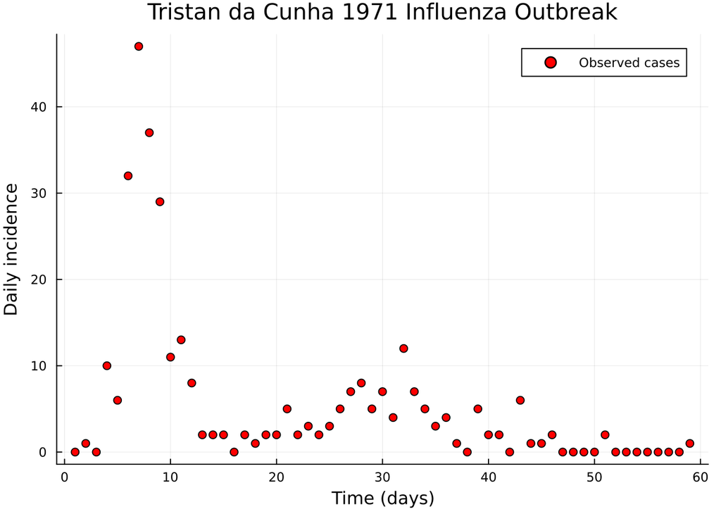

```julia
# Load data
flu_tdc = CSV.read(datadir("flu_tdc_1971.csv"), DataFrame)

# Plot
scatter(
    flu_tdc.time, flu_tdc.obs,
    xlabel = "Time (days)", ylabel = "Daily incidence",
    label = "Observed cases", markersize = 4, color = :red,
    title = "Tristan da Cunha 1971 Influenza Outbreak",
    legend = :topright
)
```

We have 59 daily observations of case counts.

# The model we are fitting

The transmission model is the deterministic SEIT4L model built in the Structure and stochasticity session, fitted here the same way as the deterministic comparison in the Particle MCMC session: $R_0$, the latent and infectious periods, the probability $\alpha$ of long-term immunity, the duration $D_\mathrm{imm}$ of temporary immunity, and $\rho$, the fraction of infections that are reported, are all fitted alongside each other. A plain SIR cannot reproduce the second wave of this outbreak at all; the model checking session diagnosed that failure, and the SEIT4L model fixes it.

These two functions live in [`src/seitl_model.jl`](https://github.com/mfiidd/mfiidd/blob/main/src/seitl_model.jl) and arrived with `using MFIIDD` above.

```julia
function seit4l_ode!(du, u, p, t)
    R_0, D_lat, D_inf, α, D_imm = p

    β = R_0 / D_inf
    ϵ = 1.0 / D_lat
    ν = 1.0 / D_inf
    τ = 4.0 / D_imm  # Rate through each T sub-stage

    S, E, I, T1, T2, T3, T4, L, Inc = u
    N = S + E + I + T1 + T2 + T3 + T4 + L

    du[1] = -β * S * I / N + (1 - α) * τ * T4  # dS/dt
    du[2] = β * S * I / N - ϵ * E              # dE/dt
    du[3] = ϵ * E - ν * I                      # dI/dt
    du[4] = ν * I - τ * T1                     # dT1/dt
    du[5] = τ * T1 - τ * T2                    # dT2/dt
    du[6] = τ * T2 - τ * T3                    # dT3/dt
    du[7] = τ * T3 - τ * T4                    # dT4/dt
    du[8] = α * τ * T4                         # dL/dt
    du[9] = ϵ * E                              # dInc/dt (cumulative)
end

function simulate_seit4l_deterministic(θ, init_state, times)
    params = [θ[:R_0], θ[:D_lat], θ[:D_inf], θ[:α], θ[:D_imm]]

    u0 = [
        init_state[:S],
        init_state[:E],
        init_state[:I],
        init_state[:T1],
        init_state[:T2],
        init_state[:T3],
        init_state[:T4],
        init_state[:L],
        0.0,
    ]

    prob = remake(SEIT4L_BASE_PROBLEM; u0 = u0, p = params, tspan = (times[1], times[end]))
    sol = solve(prob, Tsit5(), saveat = times)

    state_names = [:S, :E, :I, :T1, :T2, :T3, :T4, :L, :Inc_cumulative]
    sol_matrix = reduce(hcat, sol.u)'
    df = DataFrame(sol_matrix, state_names)
    df[!, :time] = sol.t

    df[!, :Inc] = [0.0; diff(df.Inc_cumulative)]

    return df
end
```

```julia
## `times` starts at 0.0, the left edge of the first observation day, because the
## incidence over that day is S(0) - S(1) and there is no way to form it without a
## point at 0. `traj.Inc[i + 1]` is then the incidence over the day the i-th
## observation counts
times = [0.0; flu_tdc.time]

## The island as the ship lands, at the start of day 1. Of the five islanders it
## brought back, three had been ill during the eight day voyage and are past their
## infectious period, so they start in the first stage of temporary immunity; the
## two who fell ill on landing start infectious. N = 284, the island population
init_state = Dict(
    :S => 279.0, :E => 0.0, :I => 2.0,
    :T1 => 3.0, :T2 => 0.0, :T3 => 0.0, :T4 => 0.0, :L => 0.0,
)
```

```
Dict{Symbol, Float64} with 8 entries:
  :I  => 2.0
  :T2 => 0.0
  :L  => 0.0
  :S  => 279.0
  :T4 => 0.0
  :T1 => 3.0
  :E  => 0.0
  :T3 => 0.0
```

Each fit below is checked against the data with a posterior predictive interval.

# The Poisson likelihood

## What we have used so far

This is what we’ve been doing throughout the course:

```julia
@model function seit4l_poisson(times, init_state, n_obs)
    # Weakly informative priors, as in the Particle MCMC session
    R_0 ~ truncated(Normal(3.0, 2.0), lower = 1.0)
    D_lat ~ truncated(Normal(2.0, 1.0), lower = 0.5)
    D_inf ~ truncated(Normal(3.0, 2.0), lower = 0.5)
    α ~ Beta(2, 2)
    D_imm ~ truncated(Normal(15.0, 10.0), lower = 1.0)
    ρ ~ Beta(2, 2)  # Reporting rate

    # Simulate
    θ = Dict(:R_0 => R_0, :D_lat => D_lat, :D_inf => D_inf, :α => α, :D_imm => D_imm)
    traj = simulate_seit4l_deterministic(θ, init_state, times)

    # Reject parameter draws that drive the ODE solver to fail early; the NUTS
    # gradient probe occasionally lands on combinations where it only saves a
    # few timepoints
    if nrow(traj) != length(times)
        Turing.@addlogprob! -Inf
        return
    end

    # Likelihood: Poisson observation model
    lambdas = [max(ρ * traj.Inc[i + 1], 1e-10) for i in 1:n_obs]
    obs ~ arraydist(Poisson.(lambdas))

    return traj
end
```

```
seit4l_poisson (generic function with 2 methods)
```

**NoteReminder: `arraydist` and `|` conditioning**

`obs ~ arraydist(Poisson.(lambdas))` declares a vector of independent Poisson observations, one per time point. The `|` operator, applied when creating the model instance below, conditions the model on the actual data. See the MCMC session for a full explanation of this pattern.

We fit this model:

```julia
# Fit with NUTS
model_poisson = seit4l_poisson(times, init_state, length(flu_tdc.obs)) | (; obs = flu_tdc.obs)
chain_poisson = sample(model_poisson, NUTS(0.65), 500, progress=false)
# The 0.65 is the target acceptance rate for NUTS — higher values (closer to 1)
# make the sampler more conservative, lower values allow larger steps.
# The default 0.65 works well for most models.
```

```
┌ Info: Found initial step size
└   ϵ = 0.2
```

```
╭─FlexiChain (500 iterations, 1 chain) ────────────────────────────────────────╮
│ ↓ iter  = 251:750                                                            │
│ → chain = 1:1                                                                │
│                                                                              │
│ Parameters (6) ── AbstractPPL.VarName                                        │
│  Float64  R_0, D_lat, D_inf, α, D_imm, ρ                                     │
│                                                                              │
│ Extras (14)                                                                  │
│  Int64    n_steps, tree_depth                                                │
│  Bool     is_accept, numerical_error                                         │
│  Float64  acceptance_rate, log_density, hamiltonian_energy,                  │
│           hamiltonian_energy_error, max_hamiltonian_energy_error, step_size, │
│           nom_step_size, logprior, loglikelihood, logjoint                   │
╰──────────────────────────────────────────────────────────────────────────────╯
```

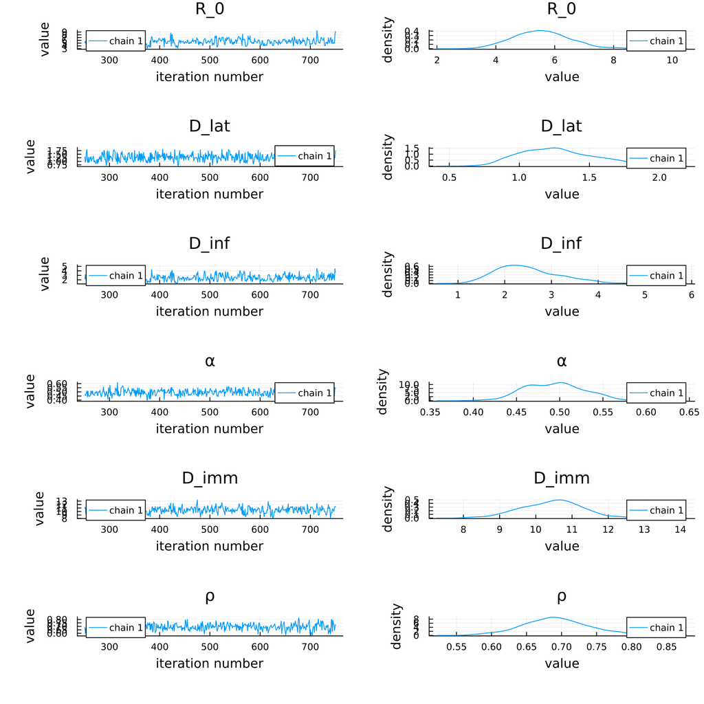

```julia
# Plot posteriors
plot(chain_poisson[[:R_0, :D_lat, :D_inf, :α, :D_imm, :ρ]], size=(900, 900))
```

```julia
# Summary statistics
summarystats(chain_poisson)
```

```
╭─FlexiSummary (9 statistics) ─────────────────────────────────────────────────╮
│   iter    collapsed                                                          │
│   chain   collapsed                                                          │
│ ↓ stat  = [mean, std, mcse, ess_bulk, ess_tail, rhat, q5, q50, q95]          │
│                                                                              │
│ Parameters (6) ── AbstractPPL.VarName                                        │
│  Float64  R_0, D_lat, D_inf, α, D_imm, ρ                                     │
│                                                                              │
│ Extras (14)                                                                  │
│  Float64  n_steps, is_accept, acceptance_rate, log_density,                  │
│           hamiltonian_energy, hamiltonian_energy_error,                      │
│           max_hamiltonian_energy_error, tree_depth, numerical_error,         │
│           step_size, nom_step_size, logprior, loglikelihood, logjoint        │
│                                                                              │
│ Summary                                                                      │
│   param     mean     std    mcse  ess_bulk  ess_tail    rhat      q5  …      │
│     R_0   5.5658  0.9737  0.0674  203.8563  242.2772  1.0043  4.0779  …      │
│   D_lat   1.2666  0.2509  0.0122  411.8555  332.4821  0.9983  0.8908  …      │
│   D_inf   2.4805  0.6488  0.0416  232.9599  215.6985  1.0071  1.5577  …      │
│       α   0.4939  0.0339  0.0020  278.8281  246.5536  1.0042  0.4425  …      │
│   D_imm  10.4350  0.8292  0.0521  252.9159  212.5937  1.0074  9.0264  …      │
│       ρ   0.6922  0.0466  0.0025  336.6842  253.4557  1.0014  0.6135  …      │
╰──────────────────────────────────────────────────────────────────────────────╯
```

## Does it reproduce the data?

Each fit is checked the same way.

```julia
function plot_predictive(model, chain, title)
    ## Draw replicate observations from the fitted model, one set per posterior draw
    predictions = predict(decondition(model), chain)
    draws = predictions[@varname(obs)]
    per_day = [[draws[i, 1][t] for i in axes(draws, 1)] for t in 1:length(flu_tdc.obs)]

    lower = [quantile(day, 0.025) for day in per_day]
    middle = [quantile(day, 0.5) for day in per_day]
    upper = [quantile(day, 0.975) for day in per_day]

    p = plot(flu_tdc.time, middle,
             ribbon = (middle .- lower, upper .- middle),
             linewidth = 2, color = :blue, fillalpha = 0.3,
             label = "95% predictive interval",
             xlabel = "Time (days)", ylabel = "Daily cases", title = title)
    scatter!(p, flu_tdc.time, flu_tdc.obs,
             label = "Observed", markersize = 3, color = :red)

    covered = count(lower .<= flu_tdc.obs .<= upper)
    return p, covered
end
```

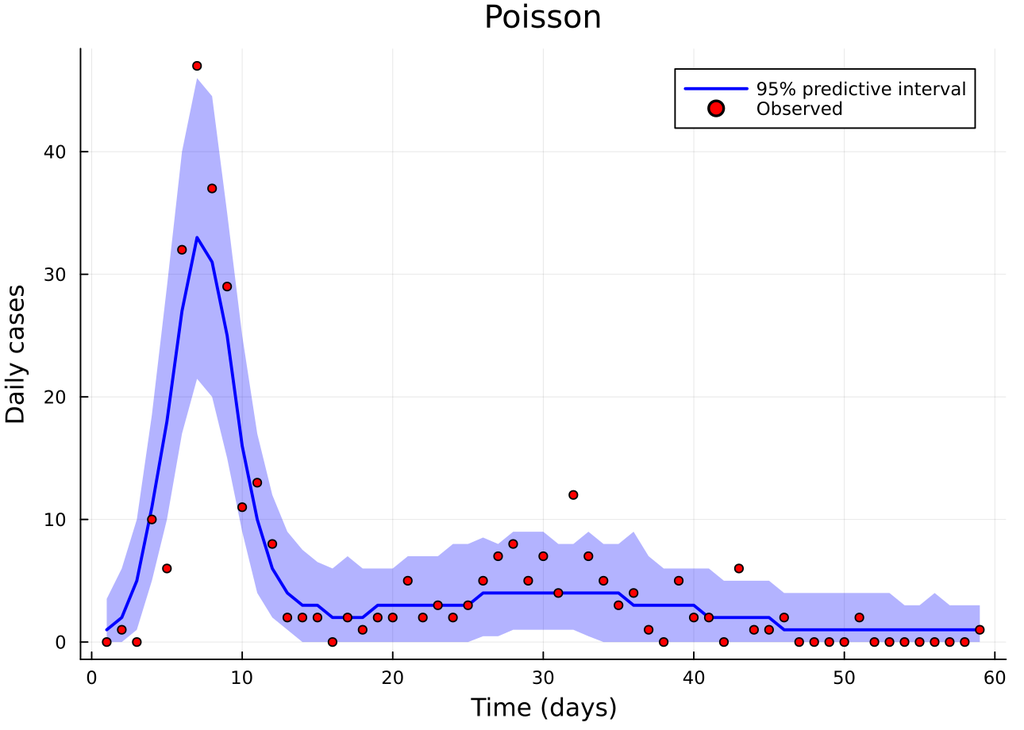

```julia
p_poisson, covered_poisson = plot_predictive(model_poisson, chain_poisson, "Poisson")
p_poisson
```

The interval covers 54 of the 59 days. A 95% interval should cover about 56.

## What does Poisson assume?

The Poisson distribution has a key property: **variance = mean**

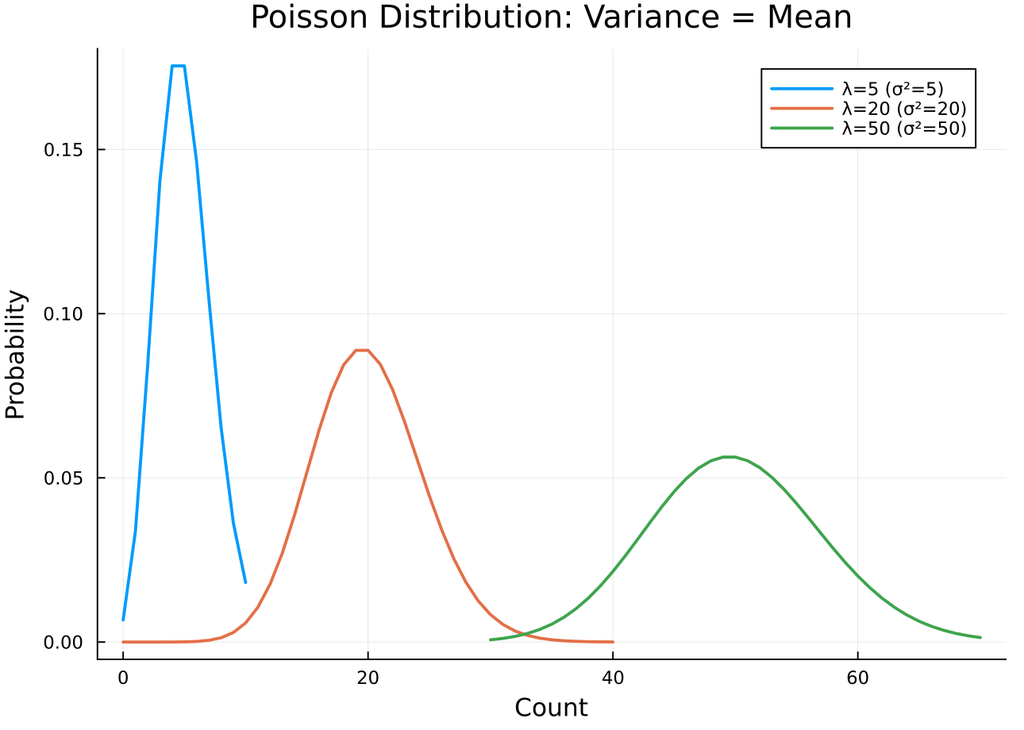

```julia
# Illustrate Poisson assumption
λ_values = [5, 20, 50]
p = plot(title="Poisson Distribution: Variance = Mean",
         xlabel="Count", ylabel="Probability")

for λ in λ_values
    dist = Poisson(λ)
    x_range = max(0, λ-20):min(λ+20, λ*2)
    plot!(p, x_range, [pdf(dist, x) for x in x_range],
          label="λ=$λ (σ²=$λ)", linewidth=2)
end
p
```

**TipExercise: Does the assumption hold for our data?**

The Poisson model claims the variance of the observations equals their mean. Check whether that is plausible for the Tristan da Cunha data.

1. Fit the Poisson model above and extract the posterior mean trajectory.
2. Compute the residuals (observed minus predicted) and their variance.
3. Compare that variance against the mean prediction. If the data were Poisson, the two should be roughly equal.

What do you find, and what would it imply for the parameter estimates?

```julia
# Residual variance against mean prediction, under the Poisson fit
θ_fit = Dict(
    :R_0 => mean(chain_poisson[:R_0]), :D_lat => mean(chain_poisson[:D_lat]),
    :D_inf => mean(chain_poisson[:D_inf]), :α => mean(chain_poisson[:α]),
    :D_imm => mean(chain_poisson[:D_imm]),
)
pred_fit = mean(chain_poisson[:ρ]) .* simulate_seit4l_deterministic(θ_fit, init_state, times).Inc[2:end]
resid_fit = flu_tdc.obs .- pred_fit

println("mean prediction:    ", round(mean(pred_fit), digits = 2))
println("residual variance:  ", round(var(resid_fit), digits = 1))
println("ratio:              ", round(var(resid_fit) / mean(pred_fit), digits = 1),
        "  (Poisson demands 1)")
```

```
mean prediction:    5.32
residual variance:  11.3
ratio:              2.1  (Poisson demands 1)
```

**TipSolution**

The ratio printed above is around 2, above the 1 Poisson demands but nothing like the failure of the single-wave SIR: that model could not reproduce a second wave at all, which is exactly what SEIT4L was built to do. The fitted trajectory follows the overall rise and fall of the first wave and predicts about 314 of the 312 reported cases in total, essentially the right amount, though individual days can miss by a dozen cases or more, as day 7 below shows.

Because the mean is no longer badly wrong, loosening the likelihood should move the posteriors much less than it would for a misspecified model. The next fit checks that.

Reasons the assumption might fail for epidemic data:

- Under-reporting might be systematic rather than random
- Behavioural changes might create clustering
- Surveillance quality might vary over time

**TipExercise: Predict what the negative binomial will change**

Before you fit it, commit to an answer for each of these. Write them down — the point is to be caught out if you are wrong.

1. Will the posterior for $R_0$ get **wider**, **narrower**, or stay about the same?
2. Will the posterior **mean** of $R_0$ move much?
3. The model adds one parameter, $\phi$. If the data were genuinely Poisson, what value would you expect the posterior for $\phi$ to favour?

Then fit it below and check.

# The negative binomial likelihood

## What does the negative binomial assume?

The negative binomial keeps the same mean and adds a second parameter, so the variance is free to exceed it:

$$\text{obs}_t \sim \text{NegativeBinomial}(\mu_t, \phi), \qquad
\text{Var}(\text{obs}_t) = \mu_t + \frac{\mu_t^2}{\phi}$$

where $\mu_t = \rho \cdot I_t$ and $\phi$ controls the overdispersion. Large $\phi$ recovers the Poisson, and small $\phi$ gives a much wider spread at the same mean.

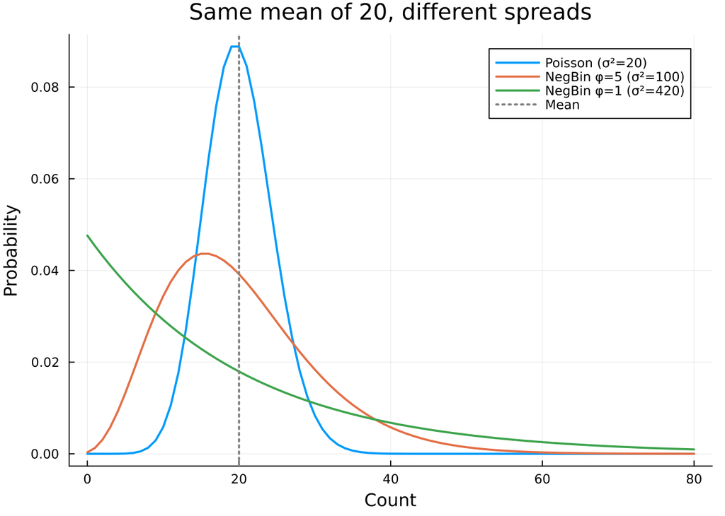

```julia
# The same mean, three observation models
counts = 0:80
p = plot(title="Same mean of 20, different spreads",
         xlabel="Count", ylabel="Probability")

plot!(p, counts, pdf.(Poisson(20), counts),
      label="Poisson (σ²=20)", linewidth=2)

for φ in [5.0, 1.0]
    ## Julia parameterises the negative binomial by (r, p), so a mean μ with
    ## overdispersion φ is r=φ and p=φ/(φ+μ)
    dist = NegativeBinomial(φ, φ/(φ+20.0))
    plot!(p, counts, pdf.(dist, counts),
          label="NegBin φ=$(Int(φ)) (σ²=$(round(Int, var(dist))))", linewidth=2)
end

vline!(p, [20], color=:grey, linestyle=:dot, linewidth=2, label="Mean")
p
```

The extra variance grows with the *square* of the mean, so a day with a high predicted count is allowed to fall further from it than a day with a low one.

Everything else the Poisson assumed still holds. Observations are conditionally independent given the trajectory, and the same fraction of infections is reported on every day. Overdispersion is the only assumption the negative binomial relaxes.

**TipExercise: what would you expect φ to be?**

Look back at the ratio of residual variance to mean prediction you computed for the Poisson fit. If that ratio came entirely from overdispersion, and the mean prediction were about 5 cases a day, roughly what $\phi$ would reproduce it?

Use $\text{Var} = \mu + \mu^2/\phi$ and solve for $\phi$.

**TipSolution**

With $\mu = 5$ and a variance twice the mean, $10 = 5 + 25/\phi$, so $\phi \approx 5$. The fit below returns a $\phi$ of about the same size, which is what should happen when the mean was already close to right: the back of an envelope calculation and the full fit agree because there is no structural misfit left for $\phi$ to paper over.

## Fitting it

```julia
@model function seit4l_negbin(times, init_state, n_obs)
    # Weakly informative priors, as in the Particle MCMC session
    R_0 ~ truncated(Normal(3.0, 2.0), lower = 1.0)
    D_lat ~ truncated(Normal(2.0, 1.0), lower = 0.5)
    D_inf ~ truncated(Normal(3.0, 2.0), lower = 0.5)
    α ~ Beta(2, 2)
    D_imm ~ truncated(Normal(15.0, 10.0), lower = 1.0)
    ρ ~ Beta(2, 2)
    φ ~ Exponential(10.0)  # Overdispersion parameter

    # Simulate
    θ = Dict(:R_0 => R_0, :D_lat => D_lat, :D_inf => D_inf, :α => α, :D_imm => D_imm)
    traj = simulate_seit4l_deterministic(θ, init_state, times)

    if nrow(traj) != length(times)
        Turing.@addlogprob! -Inf
        return
    end

    # Likelihood: Negative Binomial observation model
    mus = [max(ρ * traj.Inc[i + 1], 1e-10) for i in 1:n_obs]
    # NegativeBinomial(r, p) where r=φ, p=φ/(φ+μ)
    obs ~ arraydist([NegativeBinomial(φ, φ/(φ+μ)) for μ in mus])

    return traj
end
```

```
seit4l_negbin (generic function with 2 methods)
```

**TipCode explainer**

- [`NegativeBinomial(r, p)`](https://juliastats.org/Distributions.jl/stable/univariate/#Distributions.NegativeBinomial) - Julia’s parameterisation uses `r` (number of successes) and `p` (success probability). To get mean `μ` with overdispersion `φ`, use `r=φ` and `p=φ/(φ+μ)`. This gives variance = `μ + μ²/φ`, so larger `φ` approaches Poisson, smaller `φ` gives more overdispersion.

Now fit it, so that the predictions you just committed to can be checked.

```julia
model_negbin = seit4l_negbin(times, init_state, length(flu_tdc.obs)) | (; obs = flu_tdc.obs)
chain_negbin = sample(model_negbin, NUTS(0.65), 500, progress=false)
summarystats(chain_negbin)
```

[output not shown]

```
╭─FlexiSummary (9 statistics) ─────────────────────────────────────────────────╮
│   iter    collapsed                                                          │
│   chain   collapsed                                                          │
│ ↓ stat  = [mean, std, mcse, ess_bulk, ess_tail, rhat, q5, q50, q95]          │
│                                                                              │
│ Parameters (7) ── AbstractPPL.VarName                                        │
│  Float64  R_0, D_lat, D_inf, α, D_imm, ρ, φ                                  │
│                                                                              │
│ Extras (14)                                                                  │
│  Float64  n_steps, is_accept, acceptance_rate, log_density,                  │
│           hamiltonian_energy, hamiltonian_energy_error,                      │
│           max_hamiltonian_energy_error, tree_depth, numerical_error,         │
│           step_size, nom_step_size, logprior, loglikelihood, logjoint        │
│                                                                              │
│ Summary                                                                      │
│   param     mean     std    mcse  ess_bulk  ess_tail    rhat      q5  …      │
│     R_0   5.4668  1.1092  0.0675  266.4004  256.8732  1.0010  3.8845  …      │
│   D_lat   1.4594  0.3937  0.0251  229.7149  229.6723  1.0043  0.8676  …      │
│   D_inf   2.0910  0.7428  0.0394  341.6975  195.0044  0.9983  1.1023  …      │
│       α   0.4910  0.0443  0.0027  266.0157  337.0238  1.0024  0.4132  …      │
│   D_imm  10.2537  1.1173  0.0540  424.2046  352.3842  0.9996  8.5152  …      │
│       ρ   0.6420  0.0827  0.0060  200.3870  173.4324  0.9991  0.5136  …      │
│       φ   5.4263  2.8739  0.1563  371.6239  339.2397  1.0045  2.2150  …      │
╰──────────────────────────────────────────────────────────────────────────────╯
```

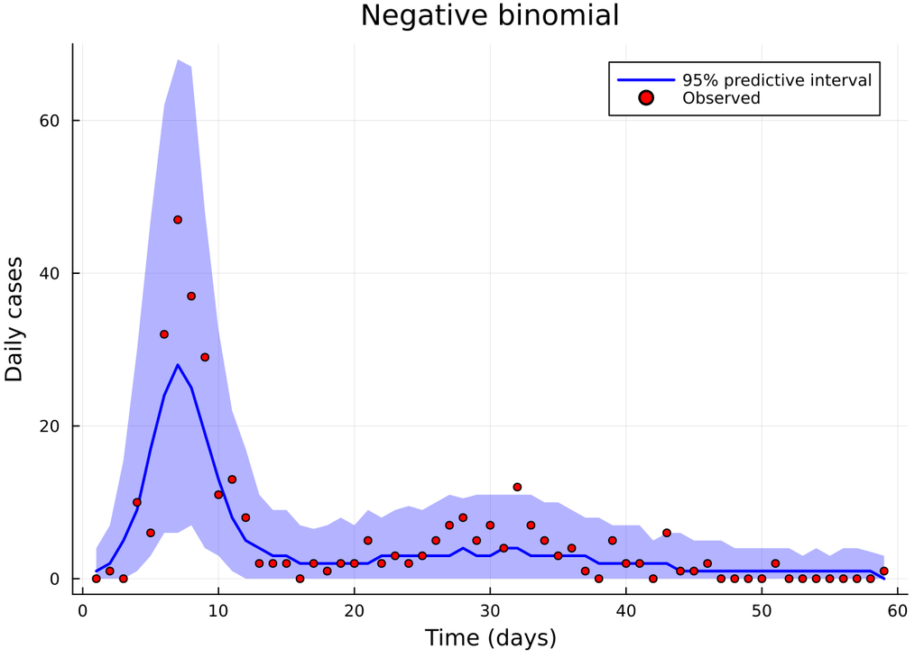

```julia
p_negbin, covered_negbin = plot_predictive(model_negbin, chain_negbin,
                                           "Negative binomial")
p_negbin
```

```julia
# Compare the two observation models on every shared parameter
params_shared = (:R_0, :D_lat, :D_inf, :α, :D_imm, :ρ)
comparison = DataFrame(
    parameter = collect(string.(params_shared)),
    poisson_mean = [mean(chain_poisson[p]) for p in params_shared],
    poisson_sd = [std(chain_poisson[p]) for p in params_shared],
    negbin_mean = [mean(chain_negbin[p]) for p in params_shared],
    negbin_sd = [std(chain_negbin[p]) for p in params_shared],
)
comparison.sd_ratio = round.(comparison.negbin_sd ./ comparison.poisson_sd, digits = 1)
comparison
```

6×6 DataFrame

| Row | parameter String | poisson_mean Float64 | poisson_sd Float64 | negbin_mean Float64 | negbin_sd Float64 | sd_ratio Float64 |
| --- | --- | --- | --- | --- | --- | --- |
| 1 | R_0 | 5.56582 | 0.973715 | 5.46681 | 1.1092 | 1.1 |
| 2 | D_lat | 1.26658 | 0.25087 | 1.45938 | 0.393738 | 1.6 |
| 3 | D_inf | 2.48051 | 0.648794 | 2.09102 | 0.742845 | 1.1 |
| 4 | α | 0.493916 | 0.0339105 | 0.491021 | 0.0443317 | 1.3 |
| 5 | D_imm | 10.435 | 0.829206 | 10.2537 | 1.11732 | 1.3 |
| 6 | ρ | 0.69219 | 0.046584 | 0.642023 | 0.0827208 | 1.8 |

**WarningCheck the chain before trusting the comparison**

Both fits here are 500 NUTS draws, which is enough to see the difference in question but not enough to report. The negative binomial chain in particular comes back with Monte Carlo standard errors of about 0.07 on $R_0$ and 0.005 on $\rho$, so the second decimal of each is already noise, however many digits the table prints. The diagnostics session is the reason you should have looked at `summarystats` before reading the table, rather than after.

```julia
# What did the data say about the overdispersion parameter?
φ_post = vec(chain_negbin[:φ])
println("φ posterior: median $(round(median(φ_post), digits = 2)), ",
        "95% interval [$(round(quantile(φ_post, 0.025), digits = 2)), ",
        "$(round(quantile(φ_post, 0.975), digits = 2))]")
```

```
φ posterior: median 4.64, 95% interval [2.03, 12.84]
```

## Why the negative binomial?

A negative binomial is a Poisson whose rate varies from day to day with a gamma distribution, so it is what you get when the reporting rate is not constant and you have not modelled why. Clustered transmission produces the same shape: household outbreaks and superspreading events deliver several cases at once, so counts vary more than independent arrivals would.

Two weaker reasons also apply. It fits these data better than the Poisson, and it is cheap to evaluate inside MCMC.

What it does not do is tell you which of those mechanisms was at work, or distinguish any of them from a mean that is simply wrong.

The two fits differ in one thing: what they charge the model for a day that misses the prediction. That charge widened $\rho$ the most above, so it is worth looking at on its own.

# Interlude: likelihood as distance

## Likelihood as distance

The negative log-likelihood is actually a *distance function* between observed and predicted data:

$$\text{Distance} = -\log p(\text{obs} | \text{predicted})$$

We can see what distance each likelihood implies:

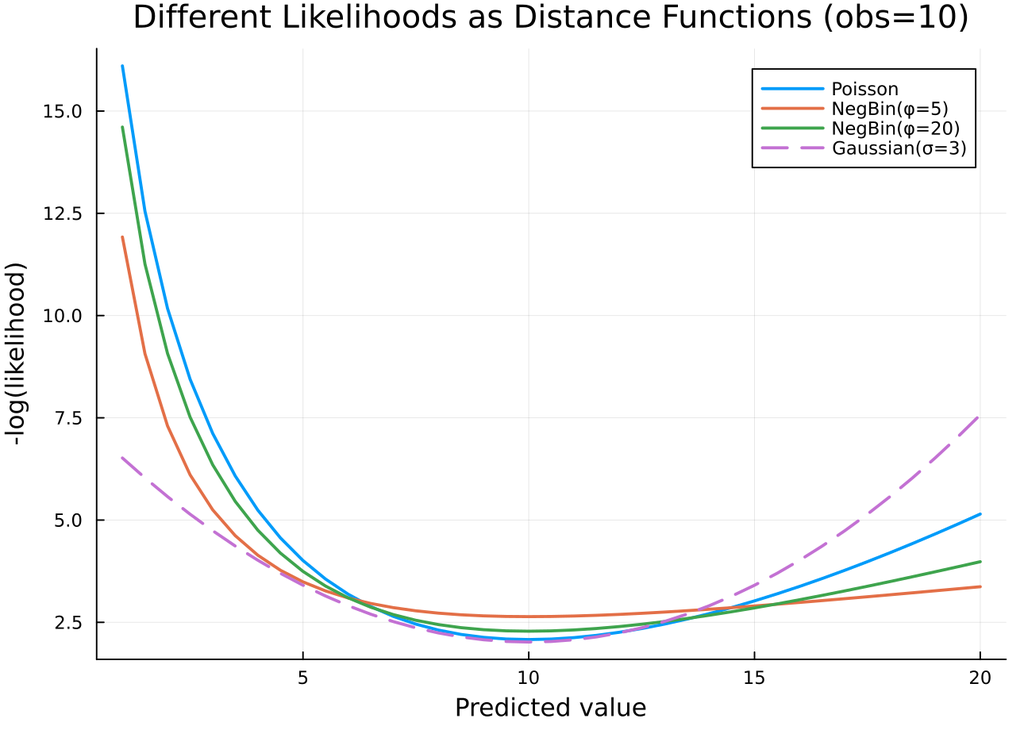

```julia
# Compare different observation models as distance functions
obs_val = 10.0
predicted_range = 1.0:0.5:20.0

# Poisson: -log P(obs | λ)
poisson_distance = [-logpdf(Poisson(λ), obs_val) for λ in predicted_range]

# Negative Binomial with different φ (convert to r,p parametrization)
# NegativeBinomial(r, p) where r=φ, p=φ/(φ+μ)
negbin_distance_phi5 = [-logpdf(NegativeBinomial(5.0, 5.0/(5.0+λ)), obs_val) for λ in predicted_range]
negbin_distance_phi20 = [-logpdf(NegativeBinomial(20.0, 20.0/(20.0+λ)), obs_val) for λ in predicted_range]

# Gaussian (for comparison)
gaussian_distance = [-logpdf(Normal(λ, 3.0), obs_val) for λ in predicted_range]

# Plot
plot(predicted_range, poisson_distance,
     label="Poisson", linewidth=2,
     xlabel="Predicted value", ylabel="-log(likelihood)",
     title="Different Likelihoods as Distance Functions (obs=10)",
     legend=:topright)
plot!(predicted_range, negbin_distance_phi5,
      label="NegBin(φ=5)", linewidth=2)
plot!(predicted_range, negbin_distance_phi20,
      label="NegBin(φ=20)", linewidth=2)
plot!(predicted_range, gaussian_distance,
      label="Gaussian(σ=3)", linewidth=2, linestyle=:dash)
```

The flat tail widened the fit. Day 7, the observed peak, reports 47 cases where the mean trajectory of the Poisson fit predicts about 33:

```julia
# What each observation model charges for day 7
day7 = findfirst(==(7), flu_tdc.time)
obs_day7, pred_day7 = flu_tdc.obs[day7], pred_fit[day7]
φ_fit = median(φ_post)

println("Poisson:  ", round(-logpdf(Poisson(pred_day7), obs_day7), digits = 1))
println("NegBin:   ", round(-logpdf(NegativeBinomial(φ_fit, φ_fit/(φ_fit+pred_day7)),
                                    obs_day7), digits = 1))
```

```
Poisson:  5.3
NegBin:   4.3
```

The Poisson is charged a little more for that single day than the negative binomial, not the order-of-magnitude gap a badly wrong mean would produce. That is the comparison table above, seen from the observation model rather than from the chain: a likelihood that charges a little less for a missed day leaves the parameters only a little freer to go elsewhere, consistent with a mean that was already close to right.

# Learning points

**TipLearning points**

- An observation model is a claim about how cases reach the data. The common choices have a mechanism behind them, and a negative binomial is a Poisson whose rate varies, which is what clustered transmission and uneven reporting both produce
- The Poisson assumption that variance equals the mean is testable, and surveillance data routinely breaks it
- A negative log-likelihood is a distance function, so choosing an observation model is choosing how to measure the gap between prediction and data
- An observation model that is too tight makes the posterior overconfident. Loosening it widens the intervals and moves the mean, but a mean that is wrong for structural reasons is not fixed by the observation model
- Some problems look like observation-model problems and are not. A delay between an event and its report, or a reporting fraction that changes part-way through an outbreak, needs a change to the model rather than a wider likelihood

**TipExercise: Which observation model for which system?**

The choice is not abstract. For each of these surveillance systems, say which observation model you would start with and what feature of the system drives the answer.

1. A sentinel network of GP practices reporting influenza-like illness weekly, with stable participation and no weekend effect.
2. Notifications of a rare disease, where a single case triggers an investigation that often finds several more in the same household.
3. Deaths in a national registry, complete but reported with a delay that varies between one and three weeks.
4. A new pathogen where testing capacity tripled part-way through the outbreak.

**TipSolution**

1. **Poisson is defensible.** Stable reporting, no obvious clustering, and cases arriving independently is roughly what Poisson assumes. Check the variance against the mean anyway rather than assuming.
2. **Negative binomial.** Case-finding around an index case produces exactly the clustering that breaks the independence assumption, and the visible symptom is variance far above the mean.
3. **Neither, on its own.** The problem here is not the spread but the *timing*: a case counted this week may belong to three weeks ago. No observation model fixes that. You need a delay distribution between the event and its report, which is a change to the model rather than to the likelihood family.
4. **Neither, again.** Tripling testing changes the proportion of infections you observe partway through, so a constant reporting fraction $\rho$ is wrong. You need $\rho$ to vary with time. Fitting a fixed $\rho$ here will make the model infer a change in transmission that never happened.

The general point: 1 and 2 are observation-model choices, 3 and 4 look like them and are not. Asking “is this about how *much* noise, or about *what* the data mean?” separates the two.

# Going further

## Other observation models

The choice of observation model affects inference more than many researchers realise. Consider exploring:

- **Gaussian likelihood**: Appropriate when counts are large and approximately symmetric
- **Zero-inflated models**: When surveillance systems miss entire days
- **Reporting delay models**: When cases are reported with variable lag

Computing the variance/mean ratio in your data can help diagnose whether Poisson (ratio ≈ 1) or Negative Binomial (ratio > 1) is more appropriate.

# Next session

If a likelihood is really a distance function that you committed to in advance by naming a distribution, an obvious question follows: what if we chose the distance directly, and never wrote a likelihood at all?

That is Approximate Bayesian computation, tomorrow morning. Worth turning over tonight: which features of these data would *you* choose to match?